# Risk Factor Analysis

## Outcome Variable

**Outcome Variable:** co_occurence

## Predictor Variables

**Intervention Variable:** ever_sstunted06

**Adjustment Set:**

- sex
- arm
- brthmon
- single
- hhwealth_quart
- W_mage
- W_mhtcm
- W_meducyrs
- W_feducyrs
- delta_brthmon
- delta_single
- delta_hhwealth_quart
- delta_W_mage
- delta_W_mhtcm
- delta_W_meducyrs
- delta_W_feducyrs

## Stratifying Variables

The analysis was stratified on these variable(s):

- studyid
- country

## Data Summary

| studyid | country | ever_sstunted06 | co_occurence | n_cell | n | outcome_variable |
| --- | --- | --- | --- | --- | --- | --- |
| CMC-V-BCS-2002 | INDIA | 0 | 0 | 261 | 366 | co_occurence |
| CMC-V-BCS-2002 | INDIA | 0 | 1 | 11 | 366 | co_occurence |
| CMC-V-BCS-2002 | INDIA | 1 | 0 | 83 | 366 | co_occurence |
| CMC-V-BCS-2002 | INDIA | 1 | 1 | 11 | 366 | co_occurence |
| CMIN | BANGLADESH | 0 | 0 | 166 | 237 | co_occurence |
| CMIN | BANGLADESH | 0 | 1 | 15 | 237 | co_occurence |
| CMIN | BANGLADESH | 1 | 0 | 45 | 237 | co_occurence |
| CMIN | BANGLADESH | 1 | 1 | 11 | 237 | co_occurence |
| COHORTS | GUATEMALA | 0 | 0 | 637 | 778 | co_occurence |
| COHORTS | GUATEMALA | 0 | 1 | 29 | 778 | co_occurence |
| COHORTS | GUATEMALA | 1 | 0 | 103 | 778 | co_occurence |
| COHORTS | GUATEMALA | 1 | 1 | 9 | 778 | co_occurence |
| COHORTS | PHILIPPINES | 0 | 0 | 2166 | 2487 | co_occurence |
| COHORTS | PHILIPPINES | 0 | 1 | 152 | 2487 | co_occurence |
| COHORTS | PHILIPPINES | 1 | 0 | 134 | 2487 | co_occurence |
| COHORTS | PHILIPPINES | 1 | 1 | 35 | 2487 | co_occurence |
| CONTENT | PERU | 0 | 0 | 193 | 200 | co_occurence |
| CONTENT | PERU | 0 | 1 | 0 | 200 | co_occurence |
| CONTENT | PERU | 1 | 0 | 7 | 200 | co_occurence |
| CONTENT | PERU | 1 | 1 | 0 | 200 | co_occurence |
| EE | PAKISTAN | 0 | 0 | 169 | 346 | co_occurence |
| EE | PAKISTAN | 0 | 1 | 27 | 346 | co_occurence |
| EE | PAKISTAN | 1 | 0 | 103 | 346 | co_occurence |
| EE | PAKISTAN | 1 | 1 | 47 | 346 | co_occurence |
| GMS-Nepal | NEPAL | 0 | 0 | 462 | 550 | co_occurence |
| GMS-Nepal | NEPAL | 0 | 1 | 47 | 550 | co_occurence |
| GMS-Nepal | NEPAL | 1 | 0 | 28 | 550 | co_occurence |
| GMS-Nepal | NEPAL | 1 | 1 | 13 | 550 | co_occurence |
| IRC | INDIA | 0 | 0 | 331 | 405 | co_occurence |
| IRC | INDIA | 0 | 1 | 13 | 405 | co_occurence |

[output cut: 78 more lines]

The following strata were considered:

- studyid: CMC-V-BCS-2002, country: INDIA
- studyid: CMIN, country: BANGLADESH
- studyid: COHORTS, country: GUATEMALA
- studyid: COHORTS, country: PHILIPPINES
- studyid: CONTENT, country: PERU
- studyid: EE, country: PAKISTAN
- studyid: GMS-Nepal, country: NEPAL
- studyid: IRC, country: INDIA
- studyid: JiVitA-4, country: BANGLADESH
- studyid: Keneba, country: GAMBIA
- studyid: LCNI-5, country: MALAWI
- studyid: MAL-ED, country: BANGLADESH
- studyid: MAL-ED, country: BRAZIL
- studyid: MAL-ED, country: INDIA
- studyid: MAL-ED, country: NEPAL
- studyid: MAL-ED, country: PERU
- studyid: MAL-ED, country: SOUTH AFRICA
- studyid: MAL-ED, country: TANZANIA, UNITED REPUBLIC OF
- studyid: NIH-Birth, country: BANGLADESH
- studyid: NIH-Crypto, country: BANGLADESH
- studyid: PROBIT, country: BELARUS
- studyid: PROVIDE, country: BANGLADESH
- studyid: ResPak, country: PAKISTAN
- studyid: SAS-CompFeed, country: INDIA
- studyid: SAS-FoodSuppl, country: INDIA
- studyid: TanzaniaChild2, country: TANZANIA, UNITED REPUBLIC OF
- studyid: ZVITAMBO, country: ZIMBABWE

### Dropped Strata

Some strata were dropped due to rare outcomes:

- studyid: CONTENT, country: PERU
- studyid: LCNI-5, country: MALAWI
- studyid: MAL-ED, country: BANGLADESH
- studyid: MAL-ED, country: BRAZIL
- studyid: MAL-ED, country: INDIA
- studyid: MAL-ED, country: NEPAL
- studyid: MAL-ED, country: PERU
- studyid: MAL-ED, country: SOUTH AFRICA
- studyid: MAL-ED, country: TANZANIA, UNITED REPUBLIC OF
- studyid: PROBIT, country: BELARUS
- studyid: PROVIDE, country: BANGLADESH
- studyid: ResPak, country: PAKISTAN

## Methods Detail

We’re interested in the causal parameters $E[Y_a]$ for all values of $a \in \mathcal{A}$. These parameters represent the mean outcome if, possibly contrary to fact, we intervened to set all units to have $A=a$. Under the randomization and positivity assumptions, these are identified by the statistical parameters $\psi_a=E_W[E_{Y|A,W}(Y|A=a,W)]$. In addition, we’re interested in the mean of $Y$, $E[Y]$ under no intervention (the observed mean). We will estimate these parameters by using SuperLearner to fit the relevant likelihood factors – $E_{Y|A,W}(Y|A=a,W)$ and $p(A=a|W)$, and then updating our likelihood fit using a joint TMLE.

For unadjusted analyses ($W=\{\}$), initial likelihoods were estimated using Lrnr_glm to estimate the simple $E(Y|A)$ and Lrnr_mean to estimate $p(A)$. For adjusted analyses, a small library containing Lrnr_glmnet, Lrnr_xgboost, and Lrnr_mean was used.

Having estimated these parameters, we will then use the delta method to estimate relative risks and attributable risks relative to a prespecified baseline level of $A$.

# Results Detail

## Results Plots

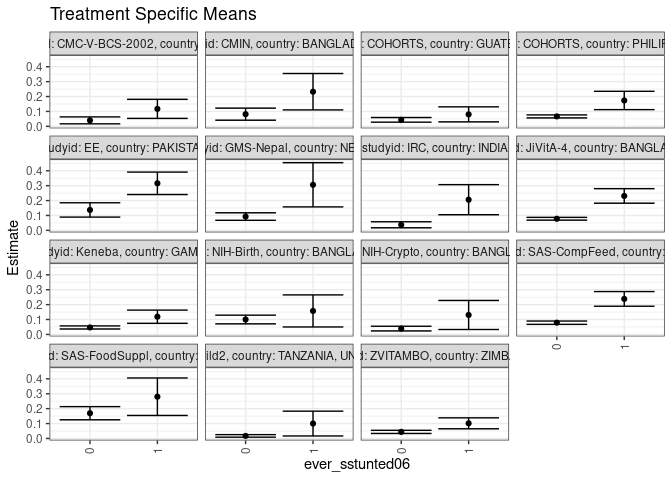

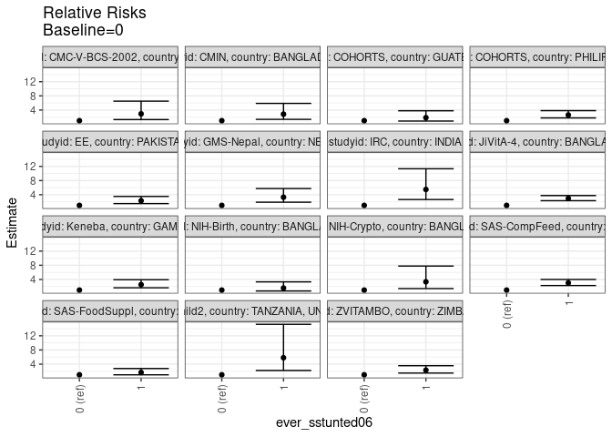

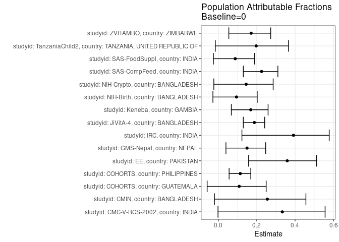

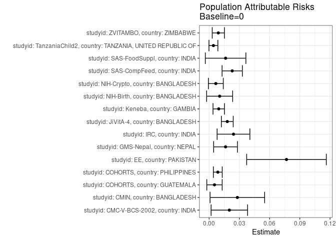

## Results Table

### Parameter: TSM

| studyid | country | intervention_level | baseline_level | estimate | ci_lower | ci_upper |
| --- | --- | --- | --- | --- | --- | --- |
| CMC-V-BCS-2002 | INDIA | 0 | NA | 0.0400715 | 0.0168316 | 0.0633115 |
| CMC-V-BCS-2002 | INDIA | 1 | NA | 0.1172326 | 0.0532267 | 0.1812386 |
| CMIN | BANGLADESH | 0 | NA | 0.0817093 | 0.0412181 | 0.1222006 |
| CMIN | BANGLADESH | 1 | NA | 0.2324184 | 0.1102386 | 0.3545982 |
| COHORTS | GUATEMALA | 0 | NA | 0.0435435 | 0.0280345 | 0.0590526 |
| COHORTS | GUATEMALA | 1 | NA | 0.0803571 | 0.0299792 | 0.1307351 |
| COHORTS | PHILIPPINES | 0 | NA | 0.0666032 | 0.0564527 | 0.0767538 |
| COHORTS | PHILIPPINES | 1 | NA | 0.1736032 | 0.1122003 | 0.2350062 |
| EE | PAKISTAN | 0 | NA | 0.1371114 | 0.0889743 | 0.1852485 |
| EE | PAKISTAN | 1 | NA | 0.3158736 | 0.2405909 | 0.3911563 |
| GMS-Nepal | NEPAL | 0 | NA | 0.0928021 | 0.0676299 | 0.1179743 |
| GMS-Nepal | NEPAL | 1 | NA | 0.3060135 | 0.1576876 | 0.4543393 |
| IRC | INDIA | 0 | NA | 0.0375636 | 0.0174002 | 0.0577269 |
| IRC | INDIA | 1 | NA | 0.2059047 | 0.1049516 | 0.3068577 |
| JiVitA-4 | BANGLADESH | 0 | NA | 0.0780094 | 0.0687721 | 0.0872467 |
| JiVitA-4 | BANGLADESH | 1 | NA | 0.2310595 | 0.1823140 | 0.2798049 |
| Keneba | GAMBIA | 0 | NA | 0.0468008 | 0.0363665 | 0.0572351 |
| Keneba | GAMBIA | 1 | NA | 0.1188851 | 0.0744756 | 0.1632947 |
| NIH-Birth | BANGLADESH | 0 | NA | 0.0999778 | 0.0707750 | 0.1291806 |
| NIH-Birth | BANGLADESH | 1 | NA | 0.1575442 | 0.0500073 | 0.2650811 |
| NIH-Crypto | BANGLADESH | 0 | NA | 0.0391156 | 0.0234332 | 0.0547981 |
| NIH-Crypto | BANGLADESH | 1 | NA | 0.1304348 | 0.0330346 | 0.2278350 |
| SAS-CompFeed | INDIA | 0 | NA | 0.0787667 | 0.0676066 | 0.0899268 |
| SAS-CompFeed | INDIA | 1 | NA | 0.2382946 | 0.1891000 | 0.2874892 |
| SAS-FoodSuppl | INDIA | 0 | NA | 0.1694384 | 0.1251980 | 0.2136788 |
| SAS-FoodSuppl | INDIA | 1 | NA | 0.2801564 | 0.1543129 | 0.4059999 |
| TanzaniaChild2 | TANZANIA, UNITED REPUBLIC OF | 0 | NA | 0.0172043 | 0.0088429 | 0.0255657 |
| TanzaniaChild2 | TANZANIA, UNITED REPUBLIC OF | 1 | NA | 0.1000000 | 0.0168033 | 0.1831967 |
| ZVITAMBO | ZIMBABWE | 0 | NA | 0.0441321 | 0.0334571 | 0.0548071 |
| ZVITAMBO | ZIMBABWE | 1 | NA | 0.1016446 | 0.0648331 | 0.1384561 |

### Parameter: E(Y)

| studyid | country | intervention_level | baseline_level | estimate | ci_lower | ci_upper |
| --- | --- | --- | --- | --- | --- | --- |
| CMC-V-BCS-2002 | INDIA | NA | NA | 0.0601093 | 0.0357249 | 0.0844936 |
| CMIN | BANGLADESH | NA | NA | 0.1097046 | 0.0698323 | 0.1495770 |
| COHORTS | GUATEMALA | NA | NA | 0.0488432 | 0.0336878 | 0.0639985 |
| COHORTS | PHILIPPINES | NA | NA | 0.0751910 | 0.0648251 | 0.0855569 |
| EE | PAKISTAN | NA | NA | 0.2138728 | 0.1706052 | 0.2571404 |
| GMS-Nepal | NEPAL | NA | NA | 0.1090909 | 0.0830130 | 0.1351688 |
| IRC | INDIA | NA | NA | 0.0617284 | 0.0382610 | 0.0851958 |
| JiVitA-4 | BANGLADESH | NA | NA | 0.0960141 | 0.0859500 | 0.1060782 |
| Keneba | GAMBIA | NA | NA | 0.0563063 | 0.0455826 | 0.0670300 |
| NIH-Birth | BANGLADESH | NA | NA | 0.1103896 | 0.0817833 | 0.1389959 |
| NIH-Crypto | BANGLADESH | NA | NA | 0.0457413 | 0.0294659 | 0.0620168 |
| SAS-CompFeed | INDIA | NA | NA | 0.1016680 | 0.0902317 | 0.1131043 |
| SAS-FoodSuppl | INDIA | NA | NA | 0.1857585 | 0.1432798 | 0.2282372 |
| TanzaniaChild2 | TANZANIA, UNITED REPUBLIC OF | NA | NA | 0.0214286 | 0.0123577 | 0.0304995 |
| ZVITAMBO | ZIMBABWE | NA | NA | 0.0532229 | 0.0425206 | 0.0639253 |

### Parameter: RR

| studyid | country | intervention_level | baseline_level | estimate | ci_lower | ci_upper |
| --- | --- | --- | --- | --- | --- | --- |
| CMC-V-BCS-2002 | INDIA | 0 | 0 | 1.000000 | 1.0000000 | 1.000000 |
| CMC-V-BCS-2002 | INDIA | 1 | 0 | 2.925583 | 1.3144590 | 6.511452 |
| CMIN | BANGLADESH | 0 | 0 | 1.000000 | 1.0000000 | 1.000000 |
| CMIN | BANGLADESH | 1 | 0 | 2.844453 | 1.3771444 | 5.875139 |
| COHORTS | GUATEMALA | 0 | 0 | 1.000000 | 1.0000000 | 1.000000 |
| COHORTS | GUATEMALA | 1 | 0 | 1.845443 | 0.8973427 | 3.795274 |
| COHORTS | PHILIPPINES | 0 | 0 | 1.000000 | 1.0000000 | 1.000000 |
| COHORTS | PHILIPPINES | 1 | 0 | 2.606529 | 1.7740869 | 3.829572 |
| EE | PAKISTAN | 0 | 0 | 1.000000 | 1.0000000 | 1.000000 |
| EE | PAKISTAN | 1 | 0 | 2.303773 | 1.5073208 | 3.521063 |
| GMS-Nepal | NEPAL | 0 | 0 | 1.000000 | 1.0000000 | 1.000000 |
| GMS-Nepal | NEPAL | 1 | 0 | 3.297485 | 1.8919381 | 5.747232 |
| IRC | INDIA | 0 | 0 | 1.000000 | 1.0000000 | 1.000000 |
| IRC | INDIA | 1 | 0 | 5.481496 | 2.6517230 | 11.331047 |
| JiVitA-4 | BANGLADESH | 0 | 0 | 1.000000 | 1.0000000 | 1.000000 |
| JiVitA-4 | BANGLADESH | 1 | 0 | 2.961944 | 2.3244958 | 3.774199 |
| Keneba | GAMBIA | 0 | 0 | 1.000000 | 1.0000000 | 1.000000 |
| Keneba | GAMBIA | 1 | 0 | 2.540237 | 1.6457236 | 3.920952 |
| NIH-Birth | BANGLADESH | 0 | 0 | 1.000000 | 1.0000000 | 1.000000 |
| NIH-Birth | BANGLADESH | 1 | 0 | 1.575792 | 0.7484501 | 3.317684 |
| NIH-Crypto | BANGLADESH | 0 | 0 | 1.000000 | 1.0000000 | 1.000000 |
| NIH-Crypto | BANGLADESH | 1 | 0 | 3.334594 | 1.4287411 | 7.782736 |
| SAS-CompFeed | INDIA | 0 | 0 | 1.000000 | 1.0000000 | 1.000000 |
| SAS-CompFeed | INDIA | 1 | 0 | 3.025321 | 2.2876465 | 4.000867 |
| SAS-FoodSuppl | INDIA | 0 | 0 | 1.000000 | 1.0000000 | 1.000000 |
| SAS-FoodSuppl | INDIA | 1 | 0 | 1.653441 | 0.9882445 | 2.766388 |
| TanzaniaChild2 | TANZANIA, UNITED REPUBLIC OF | 0 | 0 | 1.000000 | 1.0000000 | 1.000000 |
| TanzaniaChild2 | TANZANIA, UNITED REPUBLIC OF | 1 | 0 | 5.812500 | 2.2177450 | 15.234013 |
| ZVITAMBO | ZIMBABWE | 0 | 0 | 1.000000 | 1.0000000 | 1.000000 |
| ZVITAMBO | ZIMBABWE | 1 | 0 | 2.303191 | 1.4895243 | 3.561330 |

### Parameter: PAR

| studyid | country | intervention_level | baseline_level | estimate | ci_lower | ci_upper |
| --- | --- | --- | --- | --- | --- | --- |
| CMC-V-BCS-2002 | INDIA | 0 | NA | 0.0200378 | 0.0019228 | 0.0381527 |
| CMIN | BANGLADESH | 0 | NA | 0.0279953 | 0.0009247 | 0.0550659 |
| COHORTS | GUATEMALA | 0 | NA | 0.0052996 | -0.0023428 | 0.0129421 |
| COHORTS | PHILIPPINES | 0 | NA | 0.0085878 | 0.0041909 | 0.0129846 |
| EE | PAKISTAN | 0 | NA | 0.0767614 | 0.0372457 | 0.1162771 |
| GMS-Nepal | NEPAL | 0 | NA | 0.0162888 | 0.0044680 | 0.0281096 |
| IRC | INDIA | 0 | NA | 0.0241648 | 0.0079082 | 0.0404214 |
| JiVitA-4 | BANGLADESH | 0 | NA | 0.0180047 | 0.0121168 | 0.0238925 |
| Keneba | GAMBIA | 0 | NA | 0.0095055 | 0.0038306 | 0.0151804 |
| NIH-Birth | BANGLADESH | 0 | NA | 0.0104118 | -0.0025139 | 0.0233376 |
| NIH-Crypto | BANGLADESH | 0 | NA | 0.0066257 | -0.0007663 | 0.0140176 |
| SAS-CompFeed | INDIA | 0 | NA | 0.0229013 | 0.0128360 | 0.0329666 |
| SAS-FoodSuppl | INDIA | 0 | NA | 0.0163201 | -0.0038103 | 0.0364505 |
| TanzaniaChild2 | TANZANIA, UNITED REPUBLIC OF | 0 | NA | 0.0042243 | -0.0001918 | 0.0086404 |
| ZVITAMBO | ZIMBABWE | 0 | NA | 0.0090909 | 0.0030424 | 0.0151394 |

### Parameter: PAF

| studyid | country | intervention_level | baseline_level | estimate | ci_lower | ci_upper |
| --- | --- | --- | --- | --- | --- | --- |
| CMC-V-BCS-2002 | INDIA | 0 | NA | 0.3333553 | -0.0020237 | 0.5564824 |
| CMIN | BANGLADESH | 0 | NA | 0.2551879 | -0.0204805 | 0.4563884 |
| COHORTS | GUATEMALA | 0 | NA | 0.1085032 | -0.0585805 | 0.2492149 |
| COHORTS | PHILIPPINES | 0 | NA | 0.1142127 | 0.0559164 | 0.1689092 |
| EE | PAKISTAN | 0 | NA | 0.3589115 | 0.1576040 | 0.5121126 |
| GMS-Nepal | NEPAL | 0 | NA | 0.1493143 | 0.0394320 | 0.2466268 |
| IRC | INDIA | 0 | NA | 0.3914698 | 0.1227226 | 0.5778883 |
| JiVitA-4 | BANGLADESH | 0 | NA | 0.1875213 | 0.1297277 | 0.2414769 |
| Keneba | GAMBIA | 0 | NA | 0.1688178 | 0.0674356 | 0.2591783 |
| NIH-Birth | BANGLADESH | 0 | NA | 0.0943190 | -0.0285807 | 0.2025340 |
| NIH-Crypto | BANGLADESH | 0 | NA | 0.1448510 | -0.0237354 | 0.2856751 |
| SAS-CompFeed | INDIA | 0 | NA | 0.2252557 | 0.1298229 | 0.3102224 |
| SAS-FoodSuppl | INDIA | 0 | NA | 0.0878567 | -0.0259640 | 0.1890500 |
| TanzaniaChild2 | TANZANIA, UNITED REPUBLIC OF | 0 | NA | 0.1971326 | -0.0160720 | 0.3656001 |
| ZVITAMBO | ZIMBABWE | 0 | NA | 0.1708074 | 0.0544625 | 0.2728365 |